# HRP Taphonomy

Jyhreh Johnson

2023-10-05

# Materials and Methods

Data used for this project were downloaded from the Origins project website API using the following URL’s:  
1. The published hadar fossil data are available at: https://paleocore.org/origins/api/hadarfossilelements/  
2. A dataset of all skeletal elements from Uberon is also available from Origins at: https://paleocore.org/origins/api/skeletalelements/.

## Data Summary

The Hadar fossil data were merged with the Uberon skeletal element data based on the Uberon ID values to produce a dataframe with 807 rows and 9 columns. The columns include the following attributes:

| Variable | Class | Examples |
| --- | --- | --- |
| id.x | integer | 580, 164, 647, 163, 161, 648 |
| fossil | character | A.L. 438-1b, A.L. 288-1h, A.L. 444-2d, A.L. 288-1e, A.L. 288-1c/g, A.L. 444-2e |
| name | integer | Frontal bone, Frontal bone, Frontal bone, Parietal bone, Parietal bone, Parietal bone |
| uberon_id | character | UBERON:0000209, UBERON:0000209, UBERON:0000209, UBERON:0000210, UBERON:0000210, UBERON:0000210 |
| anatomical_region.y | integer | Cranial, Cranial, Cranial, Cranial, Cranial, Cranial |
| side | integer | UNK, R, UNK, UNK, UNK, L |
| dental | logical | FALSE, FALSE, FALSE, FALSE, FALSE, FALSE |
| completeness | character | fragment, fragment, NA, fragment, fragment, complete |
| preserved_part | character | nan, nan, nan, nan, nan, nan |

# Results

The data set includes 807 elements from 522 fossil specimens. There are 146 unique skeletal elements.

## Most Abundant Elements

| Element | Count | Frequency |
| --- | --- | --- |
| Mandible | 64 | 0.0793061 |
| Lower fourth secondary premolar (P4) | 27 | 0.0334572 |
| Maxilla | 24 | 0.0297398 |
| Lower third secondary premolar (P3) | 22 | 0.0272615 |
| Proximal phalanx of manus | 22 | 0.0272615 |
| Upper fourth secondary premolar (P4) | 21 | 0.0260223 |
| Femur | 20 | 0.0247831 |
| Left lower second secondary molar tooth (M2) | 20 | 0.0247831 |
| Left lower first secondary molar tooth (M1) | 18 | 0.0223048 |
| Upper third secondary premolar (P3) | 18 | 0.0223048 |

Mandibles are the most abundant element in the Hadar assemblage. They are more than twice as abundant as maxillae (64 vs 24 respectively) and this difference is significant (exact binomial test, Mandibles = 64, N = 88, p = 0 **).

### Sides

Does the data indicate any difference in the preservation of left and right sided elements? The data frame includes a column to track element side. This is a factor with five levels: BOTH, L, MID, R, UNK (unknown).

Table 1. Side counts

| side | n |
| --- | --- |
| BOTH | 27 |
| L | 316 |
| MID | 32 |
| R | 288 |
| UNK | 143 |
| NA | 1 |

The number of right and left elements is roughly the same, and not significantly different (exact binomial test, L = 316, N = 604, p = 0.2719, NS)

## Element Representation by Anatomical Region

### Observed vs Expected Element Representation

How do the element counts at Hadar compared to the expected counts if there were to be full skeletal preservation?

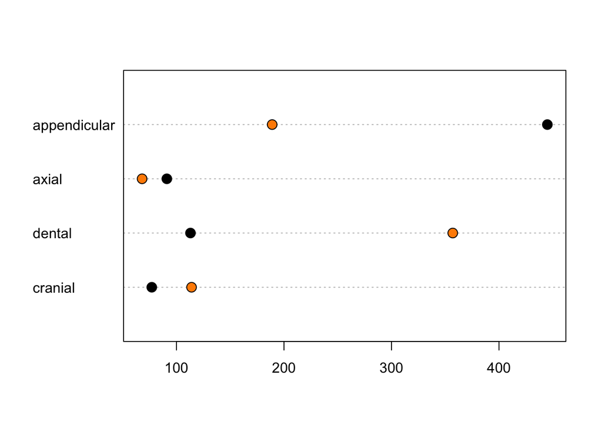

## Summaries of Expected and Observed Recorded Counts and Proportions

Table 3. Expected Regional Counts and Proportions

| regions | count | prop | exp_counts |
| --- | --- | --- | --- |
| Appendicular | 112 | 0.4072727 | 329.483636 |
| Axial | 56 | 0.2036364 | 164.741818 |
| Cranial | 28 | 0.1018182 | 82.370909 |
| Dental | 78 | 0.2836364 | 229.461818 |
| Entire | 1 | 0.0036364 | 2.941818 |

Table 4. Observed Regional Counts and Proportions

| regions | count | prop |
| --- | --- | --- |
| Appendicular | 229 | 0.2837670 |
| Axial | 76 | 0.0941760 |
| Cranial | 137 | 0.1697646 |
| Dental | 364 | 0.4510533 |
| Entire | 1 | 0.0012392 |

## Simuations

Table 5. Simulated Regional Counts

| anatomical_region | count |
| --- | --- |
| Appendicular | 315 |
| Axial | 175 |
| Cranial | 89 |
| Dental | 226 |
| Entire | 4 |

### Calculate the Distance and Euclidean Value

```
##          1        2        3        4
## 2 264.7826
## 3 410.1354 145.8474
## 4 163.9757 100.9184 246.1851
## 5 552.2914 288.3234 142.4815 388.4494
```

Attempt at running simulation

```
##              Counts Counts Counts
## Appendicular    230    235    244
## Axial            72     65     76
## Cranial         131    125    127
## Dental          374    382    359
## Entire            0      0      1
```

## Element Fragmentation Across Anatomical Region

### Completeness Counts

Table 2. Completeness Counts

| completeness | n |
| --- | --- |
| complete | 413 |
| fragment | 167 |
| nearly complete | 149 |
| NA | 78 |

### Fragmentation Analysis by anatomical region

What is the percentage distribution of completeness by region? Is their evidence of preservation bias by anatomical region?

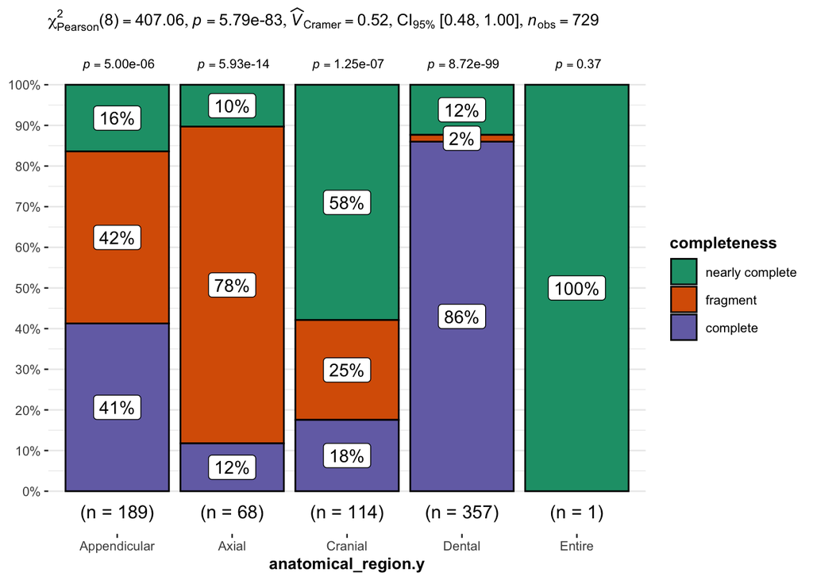

Figure 2. Completeness Distribution by Region. The green areas represent nearly complete elements, the orange is for elements that are fragmented, and the purple represents complete elements.